# Forschungspraktikum 1+2: Computational Social Science

## 3. Tokenizing the Text

Tokenization splits the text into individual units like words or phrases. In this step, we will use `quanteda`’s `tokens()` function to tokenize the cleaned text.

### a) Basic Tokenization

How many tokens are included on each page of the article?

```r
# Tokenize the text
toks_CSS_article <- tokens(CSS_article)

# Check the tokens
head(toks_CSS_article)
```

```
## Tokens consisting of 6 documents.
## text1 :
##  [1] "httpsdoiorg101007s42001024002729" "research"
##  [3] "article"                          "hostility"
##  [5] "on"                               "twitter"
##  [7] "in"                               "the"
##  [9] "aftermath"                        "of"
## [11] "terror"                           "attacks"
## [ ... and 235 more ]
##
## text2 :
##  [1] "introduction" "several"      "major"        "terror"       "attacks"
##  [6] "conducted"    "in"           "the"          "name"         "of"
## [11] "political"    "islam"
## [ ... and 552 more ]
##
## text3 :
##  [1] "marketplace" "of"          "ideas"       "23"          "one"
##  [6] "that"        "plays"       "an"          "important"   "role"
## [11] "for"         "public"
## [ ... and 498 more ]
##
## text4 :
##  [1] "the"      "first"    "set"      "of"       "studies"  "exploits"
##  [7] "the"      "fact"     "that"     "several"  "large"    "survey"
## [ ... and 539 more ]
##
## text5 :
##  [1] "types"       "of"          "disasters"   "47"          "attitudinal"
##  [6] "survey"      "studies"     "have"        "also"        "shown"
## [11] "that"        "the"
## [ ... and 497 more ]
##
## text6 :
##  [1] "more"       "peaceful"   "ones"       "may"        "leave"
##  [6] "the"        "competing"  "hypothesis" "is"         "that"
## [11] "individual" "users"
## [ ... and 474 more ]
```

```r
# How many tokens are in the text?
ntoken(toks_CSS_article) # number of tokens for each page
```

```
##  text1  text2  text3  text4  text5  text6  text7  text8  text9 text10 text11
##    247    564    510    551    509    486    480     51    524    429    449
## text12 text13 text14 text15 text16 text17 text18
##    253    517    560    196    505    556    432
```

```r
sum(ntoken(toks_CSS_article)) #  sum of total number of tokens per page
```

```
## [1] 7819
```

```r
sum(ntype(toks_CSS_article)) # sum of unique tokens per page
```

```
## [1] 4143
```

### b) Clean the Tokens

Within `quanteda`, it’s easier to further clean the text. Remove…

- Punctuation
- Numbers
- Symbols
- Separators

… in one step during tokenization. Check `?tokens()` to learn about the available options.

```r
# Tokenize and remove unwanted elements
toks_CSS_article <- tokens(toks_CSS_article,
                           remove_punct = TRUE,
                           remove_numbers = TRUE,
                           remove_symbols = TRUE,
                           remove_separators = TRUE)

# Check the tokens
head(toks_CSS_article)
```

```
## Tokens consisting of 6 documents.
## text1 :
##  [1] "httpsdoiorg101007s42001024002729" "research"
##  [3] "article"                          "hostility"
##  [5] "on"                               "twitter"
##  [7] "in"                               "the"
##  [9] "aftermath"                        "of"
## [11] "terror"                           "attacks"
## [ ... and 224 more ]
##
## text2 :
##  [1] "introduction" "several"      "major"        "terror"       "attacks"
##  [6] "conducted"    "in"           "the"          "name"         "of"
## [11] "political"    "islam"
## [ ... and 531 more ]
##
## text3 :
##  [1] "marketplace" "of"          "ideas"       "one"         "that"
##  [6] "plays"       "an"          "important"   "role"        "for"
## [11] "public"      "and"
## [ ... and 483 more ]
##
## text4 :
##  [1] "the"      "first"    "set"      "of"       "studies"  "exploits"
##  [7] "the"      "fact"     "that"     "several"  "large"    "survey"
## [ ... and 511 more ]
##
## text5 :
##  [1] "types"       "of"          "disasters"   "attitudinal" "survey"
##  [6] "studies"     "have"        "also"        "shown"       "that"
## [11] "the"         "potential"
## [ ... and 475 more ]
##
## text6 :
##  [1] "more"       "peaceful"   "ones"       "may"        "leave"
##  [6] "the"        "competing"  "hypothesis" "is"         "that"
## [11] "individual" "users"
## [ ... and 453 more ]
```

## 4. Dimensionality Reduction

### a) Stop Words

Stop words, such as “the”, “and”, or “is”, are commonly removed in text analysis since they do not add meaningful information. `quanteda` provides a list of stop words in the `stopwords()` function. How many stop words are included in this list?

```r
head(stopwords())
```

```
## [1] "i"      "me"     "my"     "myself" "we"     "our"
```

```r
length(stopwords())
```

```
## [1] 175
```

### b) Remove Stop Words

Use the `tokens_remove()` function to remove these stop words from our tokens.

```r
# Remove stop words
toks_CSS_article <- tokens_remove(toks_CSS_article, stopwords(), case_insensitive = TRUE)

# Check the remaining tokens
head(toks_CSS_article)
```

```
## Tokens consisting of 6 documents.
## text1 :
##  [1] "httpsdoiorg101007s42001024002729" "research"
##  [3] "article"                          "hostility"
##  [5] "twitter"                          "aftermath"
##  [7] "terror"                           "attacks"
##  [9] "christian"                        "s"
## [11] "czymara12"                        "anastasia"
## [ ... and 147 more ]
##
## text2 :
##  [1] "introduction" "several"      "major"        "terror"       "attacks"
##  [6] "conducted"    "name"         "political"    "islam"        "hit"
## [11] "europe"       "recent"
## [ ... and 318 more ]
##
## text3 :
##  [1] "marketplace" "ideas"       "one"         "plays"       "important"
##  [6] "role"        "public"      "political"   "discourse"   "social"
## [11] "science"     "research"
## [ ... and 304 more ]
##
## text4 :
##  [1] "first"           "set"             "studies"         "exploits"
##  [5] "fact"            "several"         "large"           "survey"
##  [9] "programs"        "hap"             "pened"           "unintentionally"
## [ ... and 318 more ]
##
## text5 :
##  [1] "types"       "disasters"   "attitudinal" "survey"      "studies"
##  [6] "also"        "shown"       "potential"   "effects"     "terrorism"
## [11] "hostility"   "tend"
## [ ... and 276 more ]
##
## text6 :
##  [1] "peaceful"   "ones"       "may"        "leave"      "competing"
##  [6] "hypothesis" "individual" "users"      "actually"   "update"
## [11] "views"      "thus"
## [ ... and 261 more ]
```

### c) Remove Frequent and Rare Tokens

Very frequent or very infrequent tokens often do not differentiate well between texts. Removing such tokens thus enables better identification of meaningful structures or frames across texts. Use `quenteda`’s `tokens_trim()` function on the token object to remove tokens that occur in *either less than 1 percent* of all texts *or more in more than 50 percent* of all texts (see `?tokens_trim()`).

How many tokens are left?

```r
toks_CSS_article <- tokens_trim(toks_CSS_article,
                                min_docfreq = 0.01,
                                max_docfreq = 0.5,
                                docfreq_type = "prop")

# Check the remaining tokens
head(toks_CSS_article)
```

```
## Tokens consisting of 6 documents.
## text1 :
##  [1] "httpsdoiorg101007s42001024002729" "research"
##  [3] "article"                          "aftermath"
##  [5] "christian"                        "s"
##  [7] "czymara12"                        "anastasia"
##  [9] "gorodzeisky1"                     "received"
## [11] "november"                         "accepted"
## [ ... and 112 more ]
##
## text2 :
##  [1] "introduction" "several"      "major"        "conducted"    "name"
##  [6] "political"    "hit"          "europe"       "recent"       "years1"
## [11] "resulting"    "dozens"
## [ ... and 281 more ]
##
## text3 :
##  [1] "marketplace" "ideas"       "one"         "plays"       "important"
##  [6] "role"        "public"      "political"   "discourse"   "social"
## [11] "science"     "research"
## [ ... and 280 more ]
##
## text4 :
##  [1] "first"           "set"             "studies"         "exploits"
##  [5] "fact"            "several"         "large"           "survey"
##  [9] "programs"        "hap"             "pened"           "unintentionally"
## [ ... and 278 more ]
##
## text5 :
##  [1] "types"       "disasters"   "attitudinal" "survey"      "studies"
##  [6] "shown"       "potential"   "effects"     "terrorism"   "tend"
## [11] "shortlived"  "abate"
## [ ... and 237 more ]
##
## text6 :
##  [1] "peaceful"   "ones"       "may"        "leave"      "competing"
##  [6] "hypothesis" "individual" "actually"   "update"     "views"
## [11] "thus"       "become"
## [ ... and 207 more ]
```

```r
# How many tokens are left?
sum(ntoken(toks_CSS_article)) #  sum of total number of tokens per page
```

```
## [1] 3718
```

```r
sum(ntype(toks_CSS_article)) # sum of unique tokens per page
```

```
## [1] 2870
```

## 5. Stemming the Tokens

Stemming reduces words to their root form, helping to group related words under a common stem. Use `tokens_wordstem()` on our cleaned tokens object for this task.

How does this affect the number of tokens per page?

```r
# Stem the tokens
toks_CSS_article <- tokens_wordstem(toks_CSS_article)

# Check the stemmed tokens
head(toks_CSS_article)
```

```
## Tokens consisting of 6 documents.
## text1 :
##  [1] "httpsdoiorg101007s42001024002729" "research"
##  [3] "articl"                           "aftermath"
##  [5] "christian"                        "s"
##  [7] "czymara12"                        "anastasia"
##  [9] "gorodzeisky1"                     "receiv"
## [11] "novemb"                           "accept"
## [ ... and 112 more ]
##
## text2 :
##  [1] "introduct" "sever"     "major"     "conduct"   "name"      "polit"
##  [7] "hit"       "europ"     "recent"    "years1"    "result"    "dozen"
## [ ... and 281 more ]
##
## text3 :
##  [1] "marketplac" "idea"       "one"        "play"       "import"
##  [6] "role"       "public"     "polit"      "discours"   "social"
## [11] "scienc"     "research"
## [ ... and 280 more ]
##
## text4 :
##  [1] "first"    "set"      "studi"    "exploit"  "fact"     "sever"
##  [7] "larg"     "survey"   "program"  "hap"      "pene"     "unintent"
## [ ... and 278 more ]
##
## text5 :
##  [1] "type"      "disast"    "attitudin" "survey"    "studi"     "shown"
##  [7] "potenti"   "effect"    "terror"    "tend"      "shortliv"  "abat"
## [ ... and 237 more ]
##
## text6 :
##  [1] "peac"      "one"       "may"       "leav"      "compet"    "hypothesi"
##  [7] "individu"  "actual"    "updat"     "view"      "thus"      "becom"
## [ ... and 207 more ]
```

```r
# How many tokens are left?
sum(ntoken(toks_CSS_article)) #  sum of total number of tokens per page
```

```
## [1] 3718
```

```r
sum(ntype(toks_CSS_article)) # sum of unique tokens per page
```

```
## [1] 2651
```

## 6. Document-Feature Matrix

A Document-Feature Matrix (DFM) is an important format for analyzing text data. It represents the frequency of terms across documents. We will now create a DFM from our cleaned, tokenized, and stemmed text data.

### a) Create the DFM

Use the `dfm()` function from `quanteda` to convert the tokens object into a DFM. How many rows and how many columns does this DFM have?

```r
# Create the DFM from tokens
dfm_CSS_article <- dfm(toks_CSS_article)

# Check the DFM
dfm_CSS_article
```

```
## Document-feature matrix of: 18 documents, 1,254 features (88.26% sparse) and 0 docvars.
##        features
## docs    httpsdoiorg101007s42001024002729 research articl aftermath christian s
##   text1                                1        1      1         1         2 2
##   text2                                0        1      0         0         0 0
##   text3                                0        5      0         0         0 0
##   text4                                0        1      0         0         0 0
##   text5                                0        1      0         0         0 0
##   text6                                0        1      0         1         0 0
##        features
## docs    czymara12 anastasia gorodzeisky1 receiv
##   text1         1         1            1      1
##   text2         0         0            0      0
##   text3         0         0            0      1
##   text4         0         0            0      0
##   text5         0         0            0      0
##   text6         0         0            0      0
## [ reached max_ndoc ... 12 more documents, reached max_nfeat ... 1,244 more features ]
```

### b) Explore the DFM

Among other things, DFMs allow us to analyze the frequency of words or terms. Let’s look at the top 10 most frequent terms in the DFM.

As an optional exercise, create a wordcloud using `textplot_wordcloud()` of the `quanteda.textplots` package to visualize the most frequent words.

```r
# Examine the top 10 most frequent terms
topfeatures(dfm_CSS_article, 10)
```

```
##  model  trend social immigr hostil  level  studi  point    use muslim
##     42     39     31     31     28     28     27     27     27     26
```

### C) Explore the DFM

Create a wordcloud using `textplot_wordcloud()` of the `quanteda.textplots` package to visualize the most frequent words.

```r
install.packages("quanteda.textplots")
```

[output not shown]

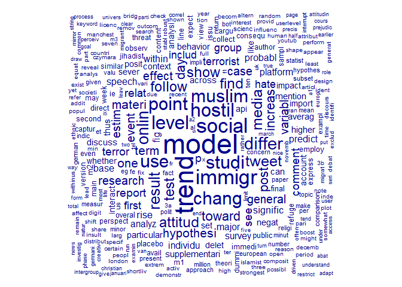

```r
library(quanteda.textplots)

textplot_wordcloud(dfm_CSS_article, rotation = 0.25)
```